# Using Neural Networks and K-Means Clustering for Accurate Wildfire Condition Detection

# Introduction

#### This Jupyter notebook is to be accompanied by the research paper written for this study. All code used for and written during this research has been presented here. This notebook will go over 2 main categories: "Dataset Construction" and "Neural Network Classifier Training and Testing", each of which will have numerous sub-categories.

# Dataset Construction

## 1. Collecting Environmental Data From the OpenWeatherMap API

```
Enter Latitude: 49.1913
Enter Longitude: -122.8490

Coordinates of one hectare polygon: [[-122.8579831528412, 49.18542884199587], [-122.84001684715881, 49.18542884199587], [-122.84001684715881, 49.197170461313], [-122.8579831528412, 49.197170461313], [-122.8579831528412, 49.18542884199587]]

Plot of 1 hectare area
```

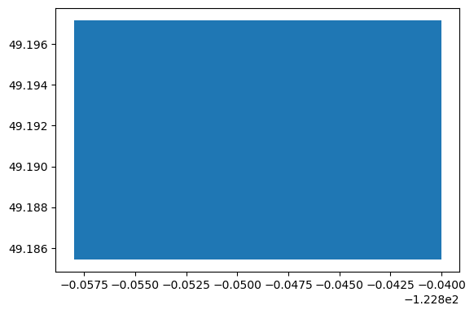

```python
import pyowm
from pyowm.utils.geo import Polygon as GeoPolygon
from pyowm.commons.enums import ImageTypeEnum
from pyowm.agroapi10.enums import SatelliteEnum, PresetEnum
from pyowm.agroapi10.enums import PaletteEnum
import requests
from pprint import pprint
import geopandas as gpd
from shapely import geometry
import json

import warnings;
warnings.filterwarnings('ignore')


#Coordinates Script
lat = str(input("Enter Latitude: "))
lon = str(input("Enter Longitude: "))
lon_float = float(lon)
lat_float = float(lat)
gdf = gpd.GeoDataFrame(geometry=[geometry.Point(lon_float, lat_float)])
gdf.crs = {'init': 'epsg:4326'}
gdf = gdf.to_crs({'init': 'epsg:3857'})
gdf['geometry'] = gdf['geometry'].apply(lambda x: x.buffer(1000).envelope)
gdf = gdf.to_crs({'init': 'epsg:4326'})
gdf.plot()
data = json.loads(gdf.to_json())

fig= plt.figure()
plt.plot(range(10))
fig.savefig("save_file_name.pdf")
plt.close()

points = data['features'][0]['geometry']['coordinates'][0]
print("\nCoordinates of one hectare polygon: " + str(points))

print("\nPlot of 1 hectare area")
```

## 1.2 Using API to gather environmental data from the previously constructed polygon

```python
def extractDigits(lst):
    return [el for el in lst]

lst = points
coordinates = [extractDigits(lst)]
lat_url = str(lat)
lon_url = str(lon)

API_key = " dae2b752022b59ac615eecbdd4b6a7c0"
base_url = "http://api.openweathermap.org/data/2.5/weather?"
Final_url = ("http://api.openweathermap.org/data/2.5/weather?appid=dae2b752022b59ac615eecbdd4b6a7c0&"+ "&lat=" + lat_url + "&lon=" + lon_url)

weather_data = requests.get(Final_url).json()

temp = ("%.1f" % ((weather_data['main']['temp']) - 273))
wind_speed = ("%.1f" % ((weather_data['wind']['speed']) * 3.6))
humidity = ("%.1f" % (weather_data['main']['humidity']))


#soil temperature script
owm = pyowm.OWM('dae2b752022b59ac615eecbdd4b6a7c0')
mgr = owm.agro_manager()

polygon_points = GeoPolygon(coordinates)

polygon = mgr.create_polygon(polygon_points, 'api test 9')
polygon.id
polygon.user_id
soil = mgr.soil_data(polygon)
soil.polygon_id
soil.reference_time(timeformat='unix')
soil_temp = ("%.3f" %(soil.surface_temp(unit='celsius')))
soil_moist = ("%.3f" %(soil.moisture))

# Printing Data
print("\nData Collected on 6/14/2020 at 8am:")
print('\nHumidity : ',humidity)
print('\nWind Speed : ',wind_speed)
print('\nTemperature : ',temp)
print('\nSoil Temperature : ',soil_temp)
print('\nSoil Moisture : ',soil_moist)
```

```
Data Collected on 6/14/2020 at 8am:

Humidity :  91.0

Wind Speed :  4.8

Temperature :  10.8

Soil Temperature :  15.480

Soil Moisture :  0.227
```

## 2. Quantifying Fuel Moisture Using NDVI Imagery and K-Means Clustering

## 2.1 Example NDVI Imagery

#### This following code will present two examples of NDVI images used from both fire scenarios.

##### Fire Conditions Not Present (High Fuel Moisture):

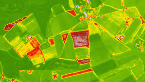

```python
from IPython.display import Image
Image("ndvi.jpg")
```

###### Fire Conditions Present (Low Fuel Moisture):

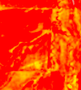

```python
from IPython.display import Image
Image("ndvi_fire_conditions.jpg")
```

## 2.2 Analysing and Comparing K-Means Output

#### This following code runs the K-means clustering algorithm on the two previous example images and delivers the RGB values of the most dominant colour along with a graphical representation of the individual pixel data.

### K-Means Clustering on "High Fuel Moisture" Imagery

```
K-Means Graphical output on high fuel moisture NDVI image:
```

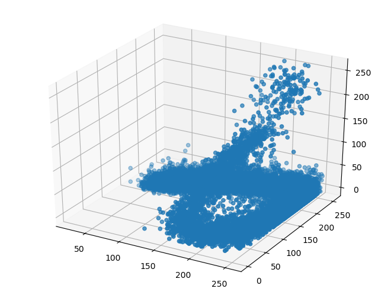

```
RGB coordinates of the most dominant colour in the high fuel moisture NDVI image: [128, 170, 8]
```

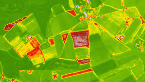

```python
import numpy as np
import matplotlib.pyplot as plt
from mpl_toolkits.mplot3d import Axes3D
from matplotlib import image as img
from sklearn.cluster import KMeans
import cv2


#Color Dominance Algorithm
def make_histogram(cluster):
    """
    Count the number of pixels in each cluster
    :param: KMeans cluster
    :return: numpy histogram
    """

    numLabels = np.arange(0, len(np.unique(cluster.labels_)) + 1)
    hist, _ = np.histogram(cluster.labels_, bins=numLabels)
    hist = hist.astype('float32')
    hist /= hist.sum()
    return hist


def make_bar(height, width, color):
    """
    Create an image of a given color
    :param: height of the image
    :param: width of the image
    :param: BGR pixel values of the color
    :return: tuple of bar, rgb values
    """
    bar = np.zeros((height, width, 3), np.uint8)
    bar[:] = color
    red, green, blue = int(color[2]), int(color[1]), int(color[0])
    return bar, (red, green, blue)

# Load image
img = cv2.imread('ndvi.jpg')
height, width, _ = np.shape(img)

# Reshape the image to be a list of RGB pixels
image = img.reshape((height * width, 3))

#convert from BGR to RGB for kmeans
img_kmeans = cv2.cvtColor(img, cv2.COLOR_BGR2RGB)

# define a cluster
num_clusters = 1
clusters = KMeans(n_clusters=num_clusters)
clusters.fit(image)

# count the dominant colors and sort them into groups
histogram = make_histogram(clusters)

# sort the groups, most-common first
combined = zip(histogram, clusters.cluster_centers_)
combined = sorted(combined, key=lambda x: x[0], reverse=True)

# get rgb values from image to 1D array
r, g, b = cv2.split(img_kmeans)
r = r.flatten()
g = g.flatten()
b = b.flatten()

# plotting
fig = plt.figure()
ax = Axes3D(fig)
ax.scatter(r, g, b)
print("K-Means Graphical output on high fuel moisture NDVI image:")
plt.show()

# output the RGB values of the most dominant colour from the "High Fuel Moisture Image"
bars = []
hsv_values = []
for index, rows in enumerate(combined):
    bar, rgb = make_bar(100, 100, rows[1])
    dominance_text = (f'  RGB values: {rgb}')
    rgb_list = list(rgb)
    print("RGB coordinates of the most dominant colour in the high fuel moisture NDVI image: " + str(rgb_list))

from IPython.display import Image
Image("ndvi.jpg")
```

### K-Means on "Low Fuel Moisture" Imagery

```
K-Means Graphical output on high fuel moisture NDVI image:
```

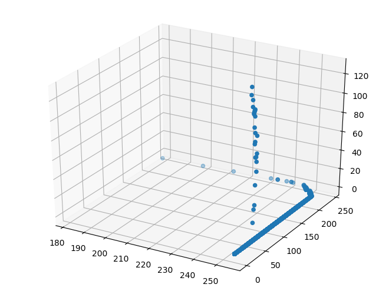

[output not shown]

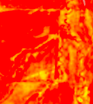

```python
import numpy as np
import matplotlib.pyplot as plt
from mpl_toolkits.mplot3d import Axes3D
from matplotlib import image as img
from sklearn.cluster import KMeans
import cv2


#Color Dominance Algorithm
def make_histogram(cluster):
    """
    Count the number of pixels in each cluster
    :param: KMeans cluster
    :return: numpy histogram
    """

    numLabels = np.arange(0, len(np.unique(cluster.labels_)) + 1)
    hist, _ = np.histogram(cluster.labels_, bins=numLabels)
    hist = hist.astype('float32')
    hist /= hist.sum()
    return hist


def make_bar(height, width, color):
    """
    Create an image of a given color
    :param: height of the image
    :param: width of the image
    :param: BGR pixel values of the color
    :return: tuple of bar, rgb values
    """
    bar = np.zeros((height, width, 3), np.uint8)
    bar[:] = color
    red, green, blue = int(color[2]), int(color[1]), int(color[0])
    return bar, (red, green, blue)

# Load image
img = cv2.imread('ndvi_fire_conditions.jpg')
height, width, _ = np.shape(img)

# Reshape the image to be a list of RGB pixels
image = img.reshape((height * width, 3))

#convert from BGR to RGB for kmeans
img_kmeans = cv2.cvtColor(img, cv2.COLOR_BGR2RGB)

# define a cluster
num_clusters = 1
clusters = KMeans(n_clusters=num_clusters)
clusters.fit(image)

# count the dominant colors and sort them into groups
histogram = make_histogram(clusters)

# sort the groups, most-common first
combined = zip(histogram, clusters.cluster_centers_)
combined = sorted(combined, key=lambda x: x[0], reverse=True)

# get rgb values from image to 1D array
r, g, b = cv2.split(img_kmeans)
r = r.flatten()
g = g.flatten()
b = b.flatten()

# plotting
fig = plt.figure()
ax = Axes3D(fig)
ax.scatter(r, g, b)
print("K-Means Graphical output on high fuel moisture NDVI image:")
plt.show()

# output the RGB values of the most dominant colour
bars = []
hsv_values = []
for index, rows in enumerate(combined):
    bar, rgb = make_bar(100, 100, rows[1])
    dominance_text = (f'  RGB values: {rgb}')
    rgb_list = list(rgb)
    print("Raw RGB coordinates of the most dominant colour in the low fuel moisture NDVI image: " + str(rgb_list))

from IPython.display import Image
Image("ndvi_fire_conditions.jpg")
```

##### Notice how the "High Fuel Moisture" imagery contains a much broader range of RGB values than the "Low Fuel Moisture" image. This is further displayed when you look at the numerical RGB coordinates. The "High Fuel Moisture"image has more balanced R(Red) and G(Green) values, along with a small B(Blue) value. However, if you consider the "Low Fuel Moisture" image, it contains a significantly higher R(Red) value, a much smaller G(Green) value, and a non-existent B(Blue) value. This will be further explored in the next section.

## 2.3 Comparing RGB values from the above images

#### This following code graphically compares the raw RGB values of the most dominant colours from both the "High Fuel Moisture" and "Low Fuel Moisture" imagery. Doing so gives us a better understanding of the relation between K-means dominant color and fuel moisture in NDVI imagery.

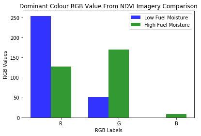

```python
import numpy as np
import matplotlib.pyplot as plt

# data to plot
n_groups = 3
kmeans_moistfuel = (128, 170, 8) # RGB values of the most dominant colour from "High Fuel Moisture" image
kmeans_dryfuel = (254, 51, 0)    # RGB values of the most dominant colour from "Low Fuel Moisture" image

# create plot
fig, ax = plt.subplots()
index = np.arange(n_groups)
bar_width = 0.35
opacity = 0.8

rects1 = plt.bar(index, kmeans_dryfuel, bar_width,
alpha=opacity,
color='b',
label='Low Fuel Moisture')

rects2 = plt.bar(index + bar_width, kmeans_moistfuel, bar_width,
alpha=opacity,
color='g',
label='High Fuel Moisture')

plt.xlabel('RGB Labels')
plt.ylabel('RGB Values')
plt.title('Dominant Colour RGB Value From NDVI Imagery Comparison')
plt.xticks(index + bar_width, ('R', 'G', 'B'))
plt.legend()

plt.tight_layout()
plt.show()
```

## 3. Dataset

## 3.1 Dataset Overview

### The following code presents the final constructed dataset used to train the neural network:

##### Indpendant Factors: Soil Moisture, Soil Temperature, Temperature, Wind Speed, Humidity, Kmeans Red, Kmeans Green, Kmeans Blue

##### Dependant Factor: Fire Conditions Present (1 = yes, 0 = no)

```python
import pandas as pd
df = pd.read_csv('dataset.csv')
print("Total # of cases where fire conditions are present: 1016")
print("Total # of cases where fire conditions are not present: 981")
df
```

```
Total # of cases where fire conditions are present: 1016
Total # of cases where fire conditions are not present: 981
```

|  | Soil Moisture | Soil Temperature | Temperature | Wind Speed | Humidity | kmeansR | kmeansG | kmeansB | Fire |
| --- | --- | --- | --- | --- | --- | --- | --- | --- | --- |
| 0 | 0.104000 | 6.250000 | 15.400000 | 25.900000 | 33.00000 | 252.00000 | 29.00000 | 18.00000 | 1 |
| 1 | 0.166000 | 5.980000 | 12.700000 | 9.400000 | 100.00000 | 64.00000 | 183.00000 | 1.00000 | 0 |
| 2 | 0.319000 | -0.440000 | -5.800000 | 16.600000 | 79.00000 | 254.00000 | 117.00000 | 1.00000 | 0 |
| 3 | 0.098000 | 14.720000 | 16.600000 | 13.600000 | 87.00000 | 245.00000 | 74.00000 | 61.00000 | 1 |
| 4 | 0.179000 | 5.890000 | 11.100000 | 8.200000 | 95.00000 | 168.00000 | 171.00000 | 0.00000 | 0 |
| ... | ... | ... | ... | ... | ... | ... | ... | ... | ... |
| 1992 | 0.081109 | 12.294374 | 32.987770 | 13.884532 | 14.94108 | 241.19172 | 105.65478 | 51.22656 | 1 |
| 1993 | 0.122730 | 19.017860 | 14.087304 | 5.762988 | 106.72200 | 73.63818 | 196.36848 | 2.13444 | 0 |
| 1994 | 0.114193 | 13.446972 | 34.161712 | 8.121544 | 21.34440 | 272.14110 | 16.00830 | 2.13444 | 1 |
| 1995 | 0.126999 | 12.144964 | 34.908766 | 10.042540 | 11.73942 | 157.94856 | 229.45230 | 1.06722 | 1 |
| 1996 | 0.302023 | 0.512266 | 4.162158 | 3.521826 | 72.57096 | 163.28466 | 192.09960 | 4.26888 | 0 |

1997 rows × 9 columns

## 3.2 Dataset Analysis

#### The following code calculates the average environmental values using the above completed dataset. It presents the average values for areas classified as "1", and for areas classified as "0".

```python
import matplotlib.pyplot as plt
#importing the dataset which ONLY has fire conditions present data
df1 = pd.read_csv('dataset_1.csv')

#collecting data from the different independant variables into lists
lst_1 = list(df1.Soil_Moisture)
lst_2 = list(df1.Soil_Temp)
lst_3 = list(df1.Temp)
lst_4 = list(df1.Wind)
lst_5 = list(df1.Humidity)
lst_6 = list(df1.kmeansr)
lst_7 = list(df1.kmeansg)
lst_8 = list(df1.kmeansb )

#finding the average values of all the independant factors
average_soil_moisture = sum(lst_1) / len(lst_1)
average_soil_temp = sum(lst_2) / len(lst_2)
average_temp = sum(lst_3) / len(lst_3)
average_wind = sum(lst_4) / len(lst_4)
average_humidity = sum(lst_5) / len(lst_5)
average_kmeansr = sum(lst_6) / len(lst_6)
average_kmeansg = sum(lst_7) / len(lst_7)
average_kmeansb = sum(lst_8) / len(lst_8)

#printing this data
print("Average Environmental Conditions in Areas With Fire Conditions Present")
print("")
print("Average Soil Moisture: " + str(average_soil_moisture))
print("Average Soil Temperature: " + str(average_soil_temp))
print("Average Temperature: " + str(average_temp))
print("Average Wind Speed: " + str(average_wind))
print("Average Humidity: " + str(average_humidity))
print("Average Kmeans R Value: " + str(average_kmeansr))
print("Average Kmeans G Value: " + str(average_kmeansg))
print("Average Kmeans B Value: " + str(average_kmeansb))

print("")
print("Average Environmental Conditions in Areas Without Fire Conditions Present")
print("")
import matplotlib.pyplot as plt
#importing the dataset which ONLY has fire conditions present data
df1 = pd.read_csv('dataset_0.csv')

#collecting data from the different independant variables into lists
lst_1 = list(df1.Soil_Moisture)
lst_2 = list(df1.Soil_Temp)
lst_3 = list(df1.Temp)
lst_4 = list(df1.Wind)
lst_5 = list(df1.Humidity)
lst_6 = list(df1.kmeansr)
lst_7 = list(df1.kmeansg)
lst_8 = list(df1.kmeansb )

#finding the average values of all the independant factos
average_soil_moisture_0 = sum(lst_1) / len(lst_1)
average_soil_temp_0 = sum(lst_2) / len(lst_2)
average_temp_0 = sum(lst_3) / len(lst_3)
average_wind_0 = sum(lst_4) / len(lst_4)
average_humidity_0 = sum(lst_5) / len(lst_5)
average_kmeansr_0 = sum(lst_6) / len(lst_6)
average_kmeansg_0 = sum(lst_7) / len(lst_7)
average_kmeansb_0 = sum(lst_8) / len(lst_8)

#printing this data
print("Average Soil Moisture: " + str(average_soil_moisture_0))
print("Average Soil Temperature: " + str(average_soil_temp_0))
print("Average Temperature: " + str(average_temp_0))
print("Average Wind Speed: " + str(average_wind_0))
print("Average Humidity: " + str(average_humidity_0))
print("Average Kmeans R Value: " + str(average_kmeansr_0))
print("Average Kmeans G Value: " + str(average_kmeansg_0))
print("Average Kmeans B Value: " + str(average_kmeansb_0))
```

```
Average Environmental Conditions in Areas With Fire Conditions Present

Average Soil Moisture: 0.1270811019370078
Average Soil Temperature: 11.809961067204723
Average Temperature: 24.888946932637825
Average Wind Speed: 10.55650030625985
Average Humidity: 42.42064780314956
Average Kmeans R Value: 203.52379291338602
Average Kmeans G Value: 113.20263830708652
Average Kmeans B Value: 26.606805543307097

Average Environmental Conditions in Areas Without Fire Conditions Present

Average Soil Moisture: 0.19642752181039755
Average Soil Temperature: 6.321897556411823
Average Temperature: 6.0218973776146765
Average Wind Speed: 8.758573419612642
Average Humidity: 84.94897482976555
Average Kmeans R Value: 190.40092317227348
Average Kmeans G Value: 162.9695088114169
Average Kmeans B Value: 13.90074861977574
```

### This following code takes the previously computed average values and graphically compares them against each other in order to further better understand the data.

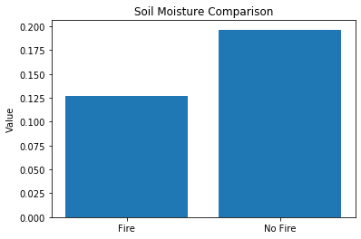

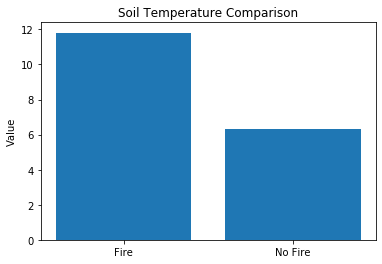

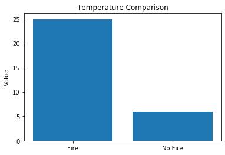

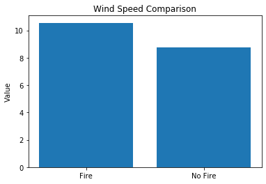

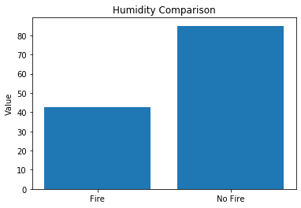

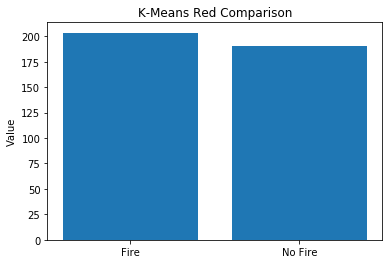

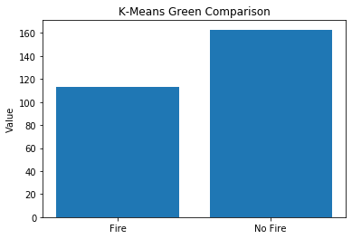

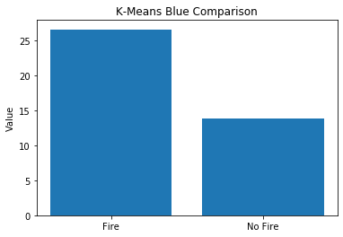

```python
labels = ['Fire', 'No Fire']

# Soil moisture plot
soil_moisture = [average_soil_moisture, average_soil_moisture_0]
y_pos = np.arange(len(labels))
plt.bar(y_pos, soil_moisture, align='center')
plt.xticks(y_pos, labels)
plt.ylabel('Value')
plt.title('Soil Moisture Comparison')
plt.show()

# Soil temperature plot
soil_temperature = [average_soil_temp, average_soil_temp_0]
y_pos = np.arange(len(labels))
plt.bar(y_pos, soil_temperature, align='center')
plt.xticks(y_pos, labels)
plt.ylabel('Value')
plt.title('Soil Temperature Comparison')
plt.show()

# Temperature plot
temperature = [average_temp, average_temp_0]
y_pos = np.arange(len(labels))
plt.bar(y_pos, temperature, align='center')
plt.xticks(y_pos, labels)
plt.ylabel('Value')
plt.title('Temperature Comparison')
plt.show()

# Wind speed plot
wind_speed = [average_wind, average_wind_0]
y_pos = np.arange(len(labels))
plt.bar(y_pos, wind_speed, align='center')
plt.xticks(y_pos, labels)
plt.ylabel('Value')
plt.title('Wind Speed Comparison')
plt.show()

# Humidity Plot
humidity = [average_humidity, average_humidity_0]
y_pos = np.arange(len(labels))
plt.bar(y_pos, humidity, align='center')
plt.xticks(y_pos, labels)
plt.ylabel('Value')
plt.title('Humidity Comparison')
plt.show()

# Kmeans Red plot
kmeansr = [average_kmeansr, average_kmeansr_0]
y_pos = np.arange(len(labels))
plt.bar(y_pos, kmeansr, align='center')
plt.xticks(y_pos, labels)
plt.ylabel('Value')
plt.title('K-Means Red Comparison')
plt.show()

# Kmeans Green plot
kmeansg = [average_kmeansg, average_kmeansg_0]
y_pos = np.arange(len(labels))
plt.bar(y_pos, kmeansg, align='center')
plt.xticks(y_pos, labels)
plt.ylabel('Value')
plt.title('K-Means Green Comparison')
plt.show()

# Kmeans Blue plot
kmeansb = [average_kmeansb, average_kmeansb_0]
y_pos = np.arange(len(labels))
plt.bar(y_pos, kmeansb, align='center')
plt.xticks(y_pos, labels)
plt.ylabel('Value')
plt.title('K-Means Blue Comparison')
plt.show()
```

# Neural Network Training and Testing

## 1. Classifier Construction

## 1.1 Classifier Summary

```python
import numpy as np
import matplotlib.pyplot as plt
import pandas as pd
import keras
from keras.models import Sequential
from keras.layers import Dense
from keras.layers import Dropout
from sklearn.preprocessing import StandardScaler
from sklearn.model_selection import train_test_split
import csv
import matplotlib.pyplot as plt
import numpy
from keras.callbacks import EarlyStopping, ModelCheckpoint

# Importing the dataset
dataset = pd.read_csv('dataset.csv')
dataset.head()

X=dataset.iloc[:,0:8]
Y=dataset.iloc[:,8]

X.head()
obj=StandardScaler()
X=obj.fit_transform(X)

X_train,X_test,y_train,y_test=train_test_split(X, Y, test_size=0.10)

classifier = Sequential()

# Adding the input layer and first hidden layer
# Adding input dim for first input layer
classifier.add(Dense(units = 8, kernel_initializer = 'uniform', activation =
                                                      'relu', input_dim = 8))
# Adding a dropout
classifier.add(Dropout(rate =  0.20))

# Adding the second hidden layer
classifier.add(Dense(units = 8, kernel_initializer = 'uniform', activation
                                                                   = 'relu'))

# Adding the output layer
classifier.add(Dense(units = 1, kernel_initializer = 'uniform', activation
                                                               = 'sigmoid'))

# Compiling the ANN
classifier.compile(optimizer = 'adam', loss = 'binary_crossentropy', metrics
                                                          = ['accuracy'])


print(X_train.shape)
print(X_test.shape)
print(y_train.shape)
print(y_test.shape)
print("")
print(classifier.summary())
```

```
(1797, 8)
(200, 8)
(1797,)
(200,)

Model: "sequential_2"
_________________________________________________________________
Layer (type)                 Output Shape              Param #
=================================================================
dense_4 (Dense)              (None, 8)                 72
_________________________________________________________________
dropout_2 (Dropout)          (None, 8)                 0
_________________________________________________________________
dense_5 (Dense)              (None, 8)                 72
_________________________________________________________________
dense_6 (Dense)              (None, 1)                 9
=================================================================
Total params: 153
Trainable params: 153
Non-trainable params: 0
_________________________________________________________________
None
```

## 1.2 Classifier Architecture

#### This following code displays the architecture of the neural network constructed for this study

```
1 Input Layer, 2 Hidden Layers, 25 Nodes, and 136 Connections
```

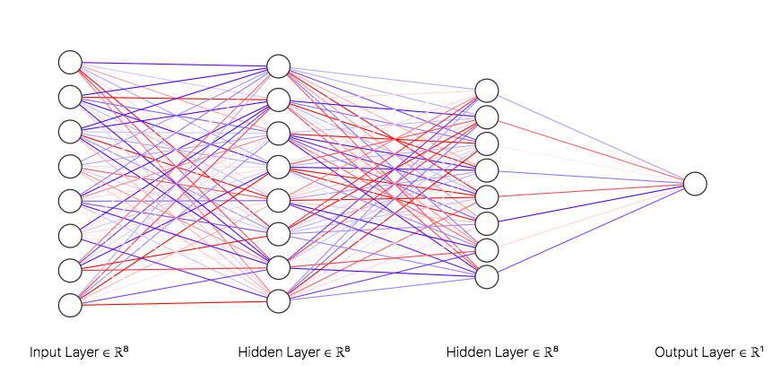

```python
print("1 Input Layer, 2 Hidden Layers, 25 Nodes, and 136 Connections")
from IPython.display import Image
Image("nn_architecture.png")
```

## 2. Artificial Neural Network (ANN) Training and Optimization

## 2.1 Original Neural Network Training

```
(1797, 8)
(200, 8)
(1797,)
(200,)
Train on 1617 samples, validate on 180 samples
```

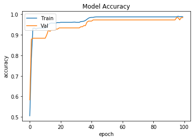

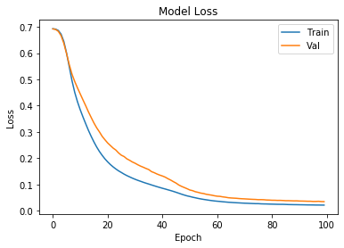

```python
import numpy as np
import matplotlib.pyplot as plt
import pandas as pd
import keras
from keras.models import Sequential
from keras.layers import Dense
from keras.layers import Dropout
from sklearn.preprocessing import StandardScaler
from sklearn.model_selection import train_test_split
import csv
import matplotlib.pyplot as plt
import numpy
from keras.callbacks import EarlyStopping, ModelCheckpoint

#THIS IS USED TO TRAIN THE MODEL

# Importing the dataset
dataset = pd.read_csv('dataset.csv')
dataset.head()

X=dataset.iloc[:,0:8]
Y=dataset.iloc[:,8]

X.head()
obj=StandardScaler()
X=obj.fit_transform(X)

X_train,X_test,y_train,y_test=train_test_split(X, Y, test_size=0.10)


print(X_train.shape)
print(X_test.shape)
print(y_train.shape)
print(y_test.shape)


classifier = Sequential()

# Adding the input layer and first hidden layer
# Adding input dim for first input layer
classifier.add(Dense(units = 8, kernel_initializer = 'uniform', activation =
                                                      'relu', input_dim = 8))
# Adding a dropout
#classifier.add(Dropout(rate =  0.10))

# Adding the second hidden layer
classifier.add(Dense(units = 8, kernel_initializer = 'uniform', activation
                                                                   = 'relu'))

# Adding the output layer
classifier.add(Dense(units = 1, kernel_initializer = 'uniform', activation
                                                               = 'sigmoid'))

# Compiling the ANN
classifier.compile(optimizer = 'adam', loss = 'binary_crossentropy', metrics
                                                          = ['accuracy'])


history = classifier.fit(X_train, y_train, validation_split=0.10, batch_size = 100, epochs = 100)
y_pred = classifier.predict(X_test)
y_pred = (y_pred > 0.96)

# summarize history for loss and accuracy (note that val stands for "validate")
plt.plot(history.history['accuracy'])
plt.plot(history.history['val_accuracy'])
plt.title('Model Accuracy')
plt.ylabel('accuracy')
plt.xlabel('epoch')
plt.legend(['Train', 'Val'], loc='upper left')
plt.show()

plt.plot(history.history['loss'])
plt.plot(history.history['val_loss'])
plt.title('Model Loss')
plt.ylabel('Loss')
plt.xlabel('Epoch')
plt.legend(['Train', 'Val'], loc='upper right')
plt.show()

# saving the classifier
classifier.save("model.h5")
```

# 2.2 Training Wildfire Conditions Model with Fine-Tuned Hyperparameters

##### This network takes advantage of our fine-tuned optimized hyperparameters and is a major improvement over the previous network. It employs a dropout with rate 0.20 after the first hidden layer to account for overfitting, a traning:validation:test split of 70:20:10, and a batch size of 9.

```
(1797, 8)
(200, 8)
(1797,)
(200,)
Train on 1437 samples, validate on 360 samples
```

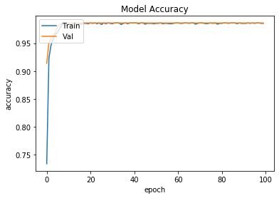

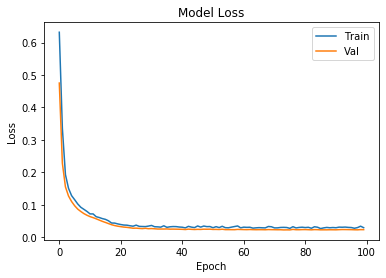

```python
import numpy as np
import matplotlib.pyplot as plt
import pandas as pd
import keras
from keras.models import Sequential
from keras.layers import Dense
from keras.layers import Dropout
from sklearn.preprocessing import StandardScaler
from sklearn.model_selection import train_test_split
import csv
import matplotlib.pyplot as plt
import numpy
from keras.callbacks import EarlyStopping, ModelCheckpoint

#THIS IS USED TO TRAIN THE MODEL

# Importing the dataset
dataset = pd.read_csv('dataset.csv')
dataset.head()

X=dataset.iloc[:,0:8]
Y=dataset.iloc[:,8]

X.head()
obj=StandardScaler()
X=obj.fit_transform(X)

X_train,X_test,y_train,y_test=train_test_split(X, Y, test_size=0.10)


print(X_train.shape)
print(X_test.shape)
print(y_train.shape)
print(y_test.shape)


classifier = Sequential()

# Adding the input layer and first hidden layer
# Adding input dim for first input layer
classifier.add(Dense(units = 8, kernel_initializer = 'uniform', activation =
                                                      'relu', input_dim = 8))
# Adding a dropout
classifier.add(Dropout(rate =  0.20))

# Adding the second hidden layer
classifier.add(Dense(units = 8, kernel_initializer = 'uniform', activation
                                                                   = 'relu'))

# Adding the output layer
classifier.add(Dense(units = 1, kernel_initializer = 'uniform', activation
                                                               = 'sigmoid'))

# Compiling the ANN
classifier.compile(optimizer = 'adam', loss = 'binary_crossentropy', metrics
                                                          = ['accuracy'])


history = classifier.fit(X_train, y_train, validation_split=0.20, batch_size = 9, epochs = 100)
y_pred = classifier.predict(X_test)
y_pred = (y_pred > 0.96)

# summarize history for loss and accuracy (note that val stands for "validate")
plt.plot(history.history['accuracy'])
plt.plot(history.history['val_accuracy'])
plt.title('Model Accuracy')
plt.ylabel('accuracy')
plt.xlabel('epoch')
plt.legend(['Train', 'Val'], loc='upper left')
plt.show()

plt.plot(history.history['loss'])
plt.plot(history.history['val_loss'])
plt.title('Model Loss')
plt.ylabel('Loss')
plt.xlabel('Epoch')
plt.legend(['Train', 'Val'], loc='upper right')
plt.show()

# saving the classifier
classifier.save("model.h5")
```

##### Training Accuracy: 98.68%

##### Validation Accuracy: 98.61%

##### As you can see, this fine-tuned model achieved a validation accuracy of 98.61% as opposed to 98.33% and shows virtually no signs of overfitting when the training and validation plots converge in the loss graph. The training was also much more accurate, more stable, and less volatile. This is the final completed model which will be used for testing.

## 3. Completed Model Testing

#### This code below will test our final model on the test dataset which contains 200 unique cases. All those different cases will be fed into the network which will output it's predictions as either a 1 (fire conditions present), or 0 (fire conditions not present). The final accuracy will be derived by dividing the number of correct predictions over 200 (the number of test cases). Note how it classifies a case as "1" only if it is atleast 95% accurate. This makes sure that the algorithm is robust and held to high standards.

```python
y_pred = classifier.predict(X_test)
# It's classified as "1" if the model is 95% sure that fire conditions are present. Else, it's "0"
y_pred=[1 if y>=0.95 else 0 for y in y_pred]
accuracy=0
for value in range (200): # The test dataset includes 200 cases
    if(y_pred[value]==list(y_test)[value]):
        accuracy+=1
print(y_pred) # Prints all the classifications made by the neural network
print("Final Test Accuracy: " + str((accuracy/200)*100) + "%") # Getting accuracy in percentage form
```

```
[1, 1, 0, 0, 0, 1, 1, 1, 0, 0, 1, 1, 1, 0, 1, 0, 1, 1, 0, 1, 0, 0, 0, 0, 1, 0, 1, 0, 1, 0, 1, 0, 0, 0, 1, 0, 0, 0, 1, 0, 0, 1, 0, 0, 1, 0, 1, 1, 1, 1, 0, 0, 0, 0, 1, 1, 1, 0, 0, 0, 1, 0, 1, 1, 0, 1, 1, 1, 0, 1, 1, 1, 0, 0, 1, 1, 0, 1, 0, 0, 0, 1, 0, 0, 0, 1, 0, 1, 0, 0, 1, 1, 1, 1, 0, 1, 1, 0, 1, 1,…
Final Test Accuracy: 98.0%
```

##### Our final completed model was able to correctly determine and classify 196/200 fire conditions cases and achieved a test accuracy of 98%

# Conclusion

With this research, artificial neural networks (ANNs) were successfully constructed and trained to classify regions on whether or not wildfire conditions were present based on environmental conditions inputs. Relying on current methods, firefighters must rely on inaccurate and highly subjective human inference and experience. However, by using a myriad of environmental conditions based on the Canadian Forest Fire Weather Index System, and by using new innovative techniques such as k-means clustering for fuel moisture quantification on NDVI imagery, a dataset was created which was used to train an artificial neural network. By taking advantage of highly optimized hyperparameters and neural network architectures, this model achieved an accuracy of 98% during testing. This has successfully demonstrated the effectiveness of our technique and will provide major needed leaps to the fields of fire dynamics, sustainable forestry management, and wildfire danger mitigation.